# Act Report

### Introduction

In this report, I am going to describe the results of exploratory analysis and visualizations.

#### Contents:

1. The most favorite dog breed according to favorite counts?
2. The most retweeted dog breeds(top 3)?
3. How favorite count is related to retweet count?
4. What are the partitions of dog stages?
5. What is the average favorite count of each dog stage?

##### The most favorite dog breed according to favorite counts?

To answer this question I first retrieved maximum favorite count by following script: `favorite_max = clean_df.favorite_count.max()`. Then, I found the breed type which has that many favorite_count via `clean_df[clean_df.favorite_count == favorite_max]['breed']`. As a result, I had Lakeland_terrier as the most favorite breed type.

##### The most retweeted dog breeds (top 3)?

To find top 3 most retweeted dog breeds I sorted dataset according to retweet count in descending order then selected top 3 breeds. I implemented this in following way: `retweet_count = clean_df.sort_values(by=['retweet_count'], ascending=False)[['retweet_count', 'breed']]` and selected top three rows `retweet_count[0:3]`. And I got this as a result.

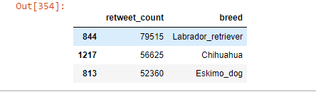

That means **Labrador_retriever**, **Chihuahua**, and **Eskimo_dog** are the breeds that are most retweeted. Specifically Labrador_retriever 79515 times, Chihuahua 56625 times, Eskimo_dog 52360 times retweeted.

##### 3. How favorite count is related to retweet count ?

Since both columns are numeric I just used df.corr() function to assess correlation coefficients of each columns. Then selected only relevant columns like `clean_df.corr()['retweet_count']['favorite_count']`. The result was 0.91 approximatelly. Then to have better idea about relationships of columns I ploted scatter plot using `clean_df.plot(kind='scatter', x='favorite_count', y='retweet_count', figsize=(5,5));`

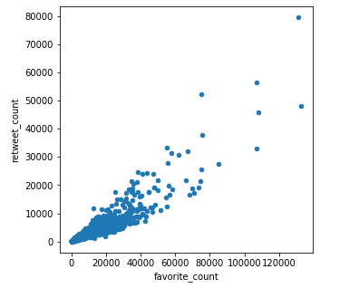

**Result:** There is a strong positive correlation between favorite count and retweeted count. Correlation coefficient is 0.91.

##### 4. What are the partitions of dog stages?

To find partitions of dog stages in dataset is not difficult job which I did using one line of code: `partitions = clean_df.groupby('stage')['tweet_id'].count()/clean_df.shape[0]`. However, to display it in a more user-friendly way I first sorted the partitions data frame so that the bar chart's bars will be displayed in from bigger to smaller partitions. Then I created a plot using matplotlib library. First I created axis and figure objects and then using axis object I created a bar graph by giving x variable as partitions.index and y variable as partitions.values*100 since values presented in percentages. Then I gave appropriate x and y axises labels and figures title. As a result, I got this

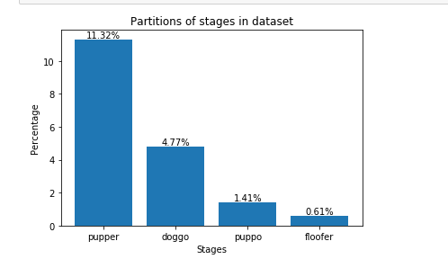

by using the following this code:

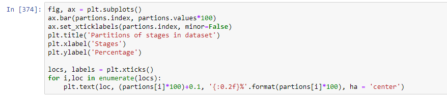

From the result above I deducted the following: Pupper, doggo, puppo, and floofer constitutes 11.32, 4.77, 1.41, 0.61 percent, respectively. All other percentage belongs to dogs which don't have stage yet.

###### 5. What is the average favorite count of each dog stage?

First, each dog stages average favorite count is calculated by grouping the dataset by stage column and taking the mean of favorite counts. `average_favorite = clean_df.groupby('stage').favorite_count.mean()` Then I sorted the resulting data frame in descending order. Then I did similar steps as a 4th question to display findings using matplotlib. And as I result I got the following bar chart

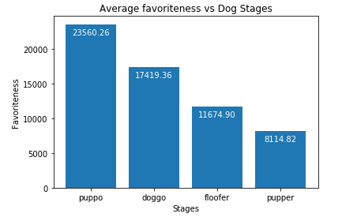